# Final Fundamentos 2023

2.3 Supongamos que ahora buscamos hacer inferencia del parámetro $\tau=log(\sigma)$, ¿cuál es el estimador de máxima verosimilitud?

```r
t_mle <- log(sqrt(est_mle))
t_mle
```

```
## [1] 2.43799
```

- Utiliza bootstrap paramétrico para generar un intervalo de confianza del 95% para el parámetro $\tau$ y realiza un histograma de las replicaciones bootstrap.

```r
set.seed(4)
crear_log_p <- function(muestra){
  log(sd(muestra))
}

rep_boot <- function(rep, crear_log_p, est_mle, n){
  muestra_bootstrap <- simular_modelo(n, 0, sqrt(est_mle))
  t_mle <- crear_log_p(muestra_bootstrap)
  tibble(parametro = "tau", estimador_boot = t_mle)
}
reps_boot <- map_dfr(1:5000, ~ rep_boot(.x, crear_log_p, est_mle, length(x)), rep = ".id")

intervalo <- quantile(reps_boot$estimador_boot, c(0.025, 0.975))
print(intervalo)
```

```
##     2.5%    97.5%
## 2.316664 2.543767
```

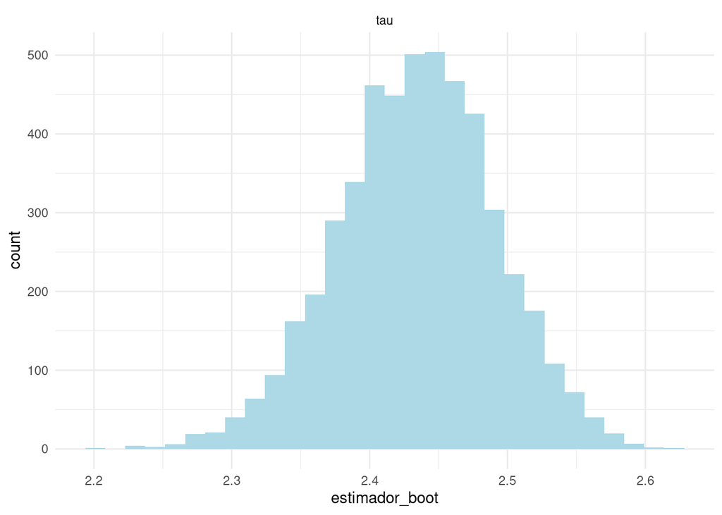

```r
ggplot(reps_boot, aes(x = estimador_boot)) +
  geom_histogram(fill="lightblue") +facet_wrap(~parametro) +
  theme_minimal()
```

- Ahora volvamos a inferencia bayesiana, calcula un intervalo de confianza para $\tau$ y un histograma de la distribución posterior de $\tau$.

```r
simulacion_posterior <- function(x, alpha, beta, n){
  alpha_posterior <- alpha + length(x) / 2
  beta_posterior <- beta + sum(x^2) / 2
  inv_gamma <- 1 / rgamma(n=n, shape=alpha_posterior, rate=beta_posterior)
  posterior <- log(sqrt(inv_gamma))
  posterior
}

posterior_t <- simulacion_posterior(simular_modelo(length(x), 0, sqrt(est_mle)),alpha, beta, 5000)
intervalo_p <- quantile(posterior_t, c(0.025, 0.975))
print(intervalo_p)
```

```
##     2.5%    97.5%
## 2.282117 2.504824
```

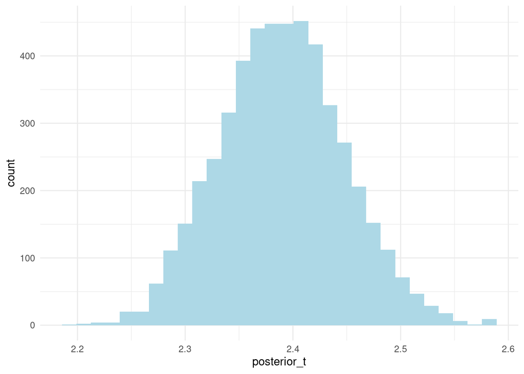

```r
#plot
ggplot(data.frame(posterior_t), aes(x = posterior_t)) +
  geom_histogram(fill="lightblue") +
  theme_minimal()
```

### 3. Bayesiana y regularización

Los datos *pew_research_center_june_elect_wknd_data.dta* tienen información de encuestas realizadas durante la campaña presidencial 2008 de EUA.

- Estima el porcentaje de la población de cada estado (excluyendo Alaska, Hawai, y DC) que se considera *very liberal*, utilizando el estimador de máxima verosimilitud.

### Estimación del porcentaje para toda la pobleción

**Considerando una distribución binomial, tenemos que el estimador de máxima verosimilitud es:** $\hat p\frac{k}{n}$

```r
n_tot = nrow(datos1)
k_tot = 1470
p_hat_tot = k_tot / n_tot
p_hat_tot
```

```
## [1] 0.04711387
```

*otra forma de calcularlo es:*

```r
crear_log_bi <- function(n,k){
  log_verosimilitud <- function(p){
  k * log(p) + (n-k) * log(1-p)
  }
  log_verosimilitud
}
```

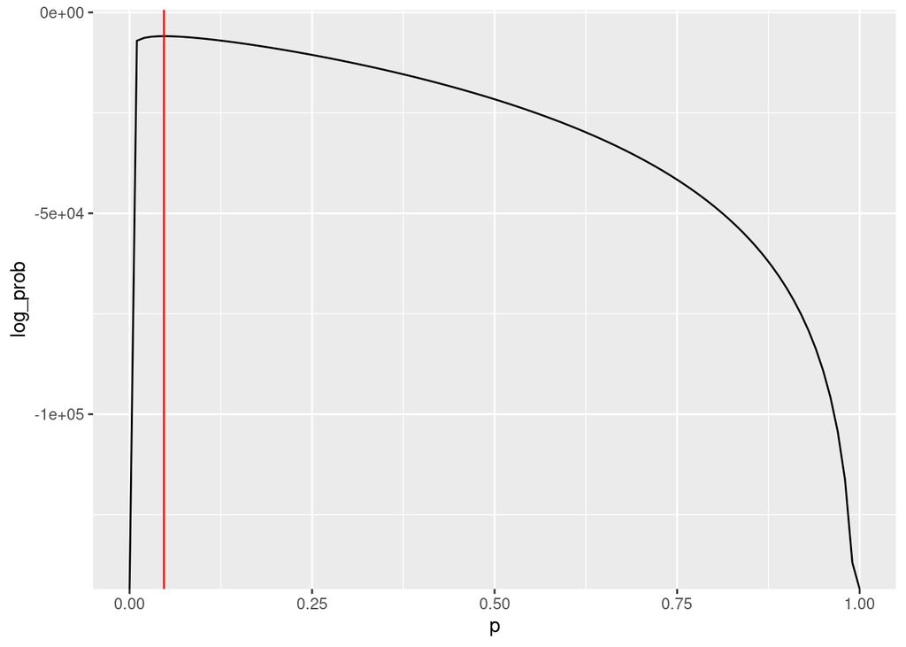

```r
log_verosimilitudBI <- crear_log_bi(n_tot,k_tot)

dat_verosim <- tibble(x = seq(0,1, 0.01)) %>% mutate(log_prob = map_dbl(x, log_verosimilitudBI))
ggplot(dat_verosim, aes(x = x, y = log_prob)) + geom_line() +
  geom_vline(xintercept = p_hat_tot, color = "red") +
  xlab("p")
```

```r
solucion <- optim(p = 0.05, log_verosimilitudBI, control = list(fnscale = -1))
solucion$par
```

```
## [1] 0.04710937
```